# Philadelphia Housing Model - Technical Appendix

Authors

Angel Rutherford

Ixchel Ramirez

Qianmu Zheng

Xiao Yu

Yanyang Chen

# Phase 1: Data Preparation

In this analysis, we attempt to measure what factors we can use to predict the sale prices of residential properties in Philadelphia. In order to prepare the dataset for modeling residential property sales, we applied a series of targeted cleaning and structural, socioeconomic, and spatial variable selection.

We filtered our property sales data to only show sales for the past two years to ensure up-to-date insights. We restricted the dataset to `"SINGLE FAMILY"` and `"MULTI FAMILY"` homes, excluding apartments and non-residential sales to ensure comparability, relevancy, and accuracy in our prediction models. Various apartments contained within the same building were found to be listed with a comprehensive sales price of the entire building which posed the threat of distorting our analysis. Observation values that were regarded as data entry errors or outliers were also removed. Properties with zero bathrooms, bedrooms, or livable area were removed as well as properties with a sales price below $10,000 and above $1,000,000.

We retained select structural attributes from our original dataset that we considered theoretically relevant to predicting sale price: number of bedrooms, number of bathrooms, total livable area, year the home was built, exterior condition, availability of garage spaces, and finally, the dependent variable, sale price.

**Code for Property Sales Data Cleaning and Variable Selection**

```r
#load necessary libraries
library(modelsummary)
library(stargazer)
library(sf)
library(tigris)
library(tidycensus)
library(dplyr)
library(stringr)
library(ggplot2)
library(tidyr)
library(caret)
library(knitr)
library(scales)

#load census key for later use
census_api_key("42bf8a20a3df1def380f330cf7edad0dd5842ce6")

#save data in url
url <- "https://phl.carto.com/api/v2/sql?filename=opa_properties_public&format=geojson&skipfields=cartodb_id&q=SELECT+*+FROM+opa_properties_public"

#suppress warnings for clarity and read data as spatial object
suppressWarnings({
 property_data <- st_read(url)
})

#clean data
parcel_data <- property_data%>%
  select(location, #load columns that could potentially be used as predictors
         category_code_description, #maybe garage_spaces and central air too?
         number_of_bedrooms,
         number_of_bathrooms,
         total_livable_area,
         year_built,
         exterior_condition,
         garage_spaces,
         sale_price,
         sale_date)%>%
  filter(category_code_description %in%
  c("SINGLE FAMILY","MULTI FAMILY"))%>% #no apartments, sales price of building
  drop_na(number_of_bedrooms, #remove anomalies like houses with no rooms
          number_of_bathrooms,
          total_livable_area,
          sale_price,
          year_built) %>%
  filter(number_of_bedrooms>0,
         number_of_bathrooms>0,
         total_livable_area>0,
         sale_price>=10000, sale_price <=1000000)%>% #remove very low/high prices
  mutate(sale_year = str_remove(sale_date, "-.*"))%>%
  filter(sale_year %in% c("2023","2024"))%>% #limit to only 2023 and 2024
  mutate(year_built = as.numeric(year_built))%>%
  mutate(Age = 2025 - year_built)%>% filter(Age <2000)%>% #create a age column
  filter(exterior_condition != 0) %>% #create exterior condition binary
  mutate(
    exterior_good = case_when(
      exterior_condition >= 1 & exterior_condition <= 5 ~ 1,
      exterior_condition >= 6 & exterior_condition <= 9 ~ 0,
      TRUE ~ NA_real_
    )
  )
```

Table 1. Property Dataset Dimensions Before and After Cleaning and Selecting Varaiables

| Dataset | Rows | Columns |
| --- | --- | --- |
| Raw Property Data | 583558 | 80 |
| Cleaned Parcel Data | 26694 | 14 |

We derived our socioeconomic predictors from tract-level census data provided by the 2022 American Community Survey: median income, number with at least a bachelor’s degree, total number of those with at least a bachelor’s degree, number of those living in poverty, and total of those living in poverty. Census tracts with missing median income or zero reported as the median income were removed as it often indicated missing or zero values for other key predictors. We also mutated our census dataset to include two more columns, the percentage of people with bachelors and percentage of people in poverty, in order to standardize the observations across varying tract population sizes. Spatial data of the census tracts was also loaded in order to join our census variables to our parcel-level property data.

**Code for Census Data Cleaning and Variable Selection**

```r
#load data about poverty(counts and total), bachelors(counts and total), and income
census_data <- get_acs(
  geography = "tract",
  state = "PA",
  county = "Philadelphia",
  variables = c(
    median_income = "B19013_001",
    num_with_bach = "B15003_022",
    bachelors_total ="B15003_001",
    num_in_poverty = "B17001_002",
    poverty_total ="B17001_001"
  ),
  year = 2022,
  output = "wide"
)

#create percentage columns for bachelors and poverty
philly_census <- census_data%>%
  mutate(
    percentage_bach = num_with_bachE / bachelors_totalE,
    percentage_pov =  num_in_povertyE / poverty_totalE
  )

#remove data errors or incomplete fields
philly_census <- philly_census%>%
  drop_na(median_incomeE)%>%
  filter(median_incomeE>0)


#spatial census data
philadelphia_tracts <- tracts(
  state = "PA",
  county = "Philadelphia",
  cb = TRUE,
  year = 2022
)

#join census data and tract geometry to PARCEL data
parcel_data <- parcel_data %>%
  st_transform(st_crs(philadelphia_tracts))%>%
  st_join(philadelphia_tracts, join = st_within)%>%
  left_join(philly_census, by = "GEOID")
```

Table 2. Census Dataset Dimensions Before and After Cleaning and Selecting Varaiables

| Dataset | Rows | Columns |
| --- | --- | --- |
| Census Data | 408 | 12 |
| Cleaned Census Data | 383 | 14 |

To further contextualize house prices, we loaded spatial datasets including the locations of colleges and universities, 2024 crime incidents, and Philadelphia neighborhood boundaries. These datasets were loaded with the intention of engineering spatial features such as proximity measurements and neighborhood stratification in order to account for spatial patterns and potential interactive spatial effects within our predictive model. Only the 2024 crime incidents needed to be cleaned due to the missing geometries that would prevent spatial analysis.

**Code for Spatial Data Cleaning and Variable Selection**

```r
#load university data
university_data <- st_read("./data/Universities_Colleges.geojson")

#load 2024 crime incident data
org_crime_data <-st_read("./data/incidents_part1_part2.shp")

#removed crime incidents with no geometry
crime_data <- org_crime_data %>%
  filter(!st_is_empty(geometry))

#load neighborhood data
neighborhoods <- st_read("./data/philadelphia-neighborhoods.shp")
```

Table 3. Spatial Datasets Dimensions Before and After Cleaning

| Dataset | Rows | Columns |
| --- | --- | --- |
| Crime Data | 160388 | 14 |
| Cleaned Crime Data | 153644 | 14 |

# Phase 2: Exploratory Data Analysis

We created a histogram to visualize the distribution of home sale prices in Philadelphia. The resulting graph revealed a positively skewed distribution, indicating that most properties were sold at lower price points, primarily between $150,000 and $350,000, while a small number of high-value homes sold for up to $1,000,000. As it pertains to our predictive model, this skewness suggests that a log-transformation of sale prices may be necessary to normalize the distribution of values and potentially improve model performance. It also indicates the need for diagnostic checks to determine the impact of outliers in order to ensure that the few high-priced homes do not distort our model estimates.

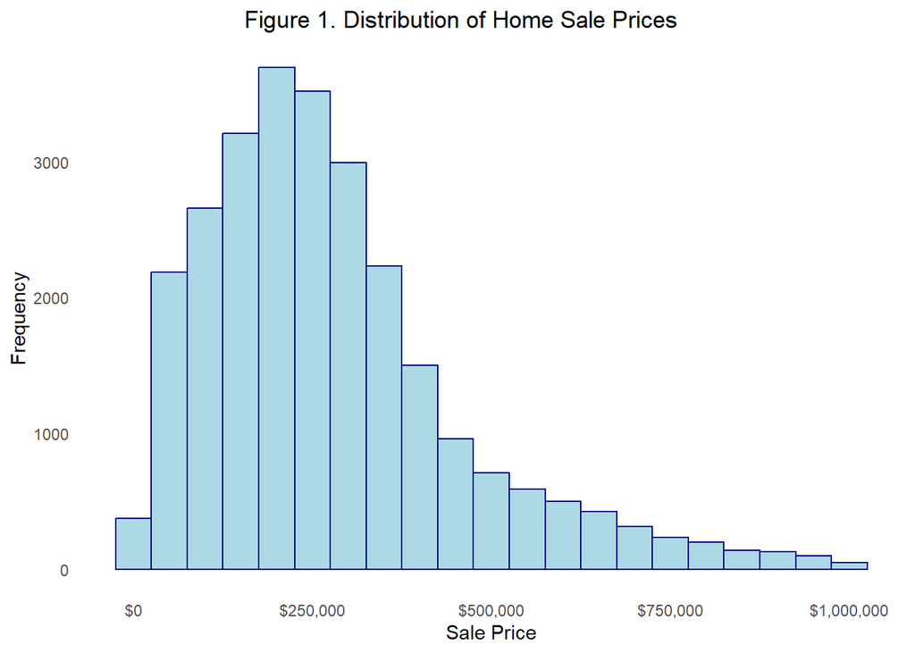

We also explored the geographic distribution of sales prices across the neighborhoods in Philadelphia. We calculated the median sales price by each Philadelphia neighborhood. The map in Figure 2 shows distinct spatial patterns with higher prices above $400,000, represented by lighter colors, being concentrated in neighborhoods such as Center City, University City, and parts of Northwest Philadelphia.

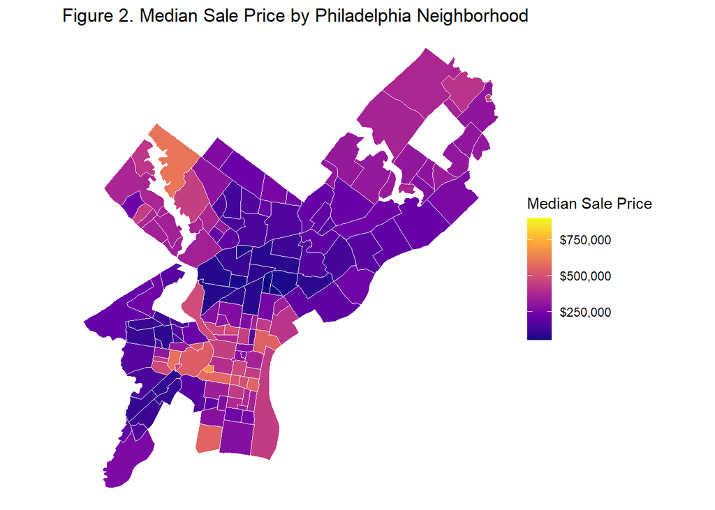

One interesting relationship we found when exploring the structural predictors of sales price was the non-linear association between home age and sale price. Because we have already determined that sale prices are not normally distributed, we plotted our predictors by the log-transformed sale price to limit distortion when attempting to assess the relationship between predictors and sales price. Even with this transformation, Figure 3 shows that sale prices tend to decline for middle-aged homes but rebound for older, more historic properties. The figure includes both a linear and quadratic line to further emphasize that a linear relationship is not sufficient in capturing the impact of age on house prices.

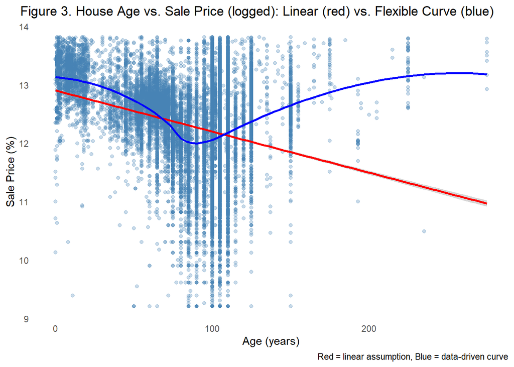

One spatial factor that we found theoretically relevant to predicting sales price was proximity to violent crimes. We hypothesized that a home’s proximity to violent crimes such as homicides, aggravated assaults with and without firearms, and armed robberies may lead to a depreciation in house value. To measure this, loaded the location of crime incidents 2024 and calculated the density of crime within 600 feet of each home. In Figure 4 we explored this relationship between violent crimes and found a general negative trend between proximity to crime and sale price.

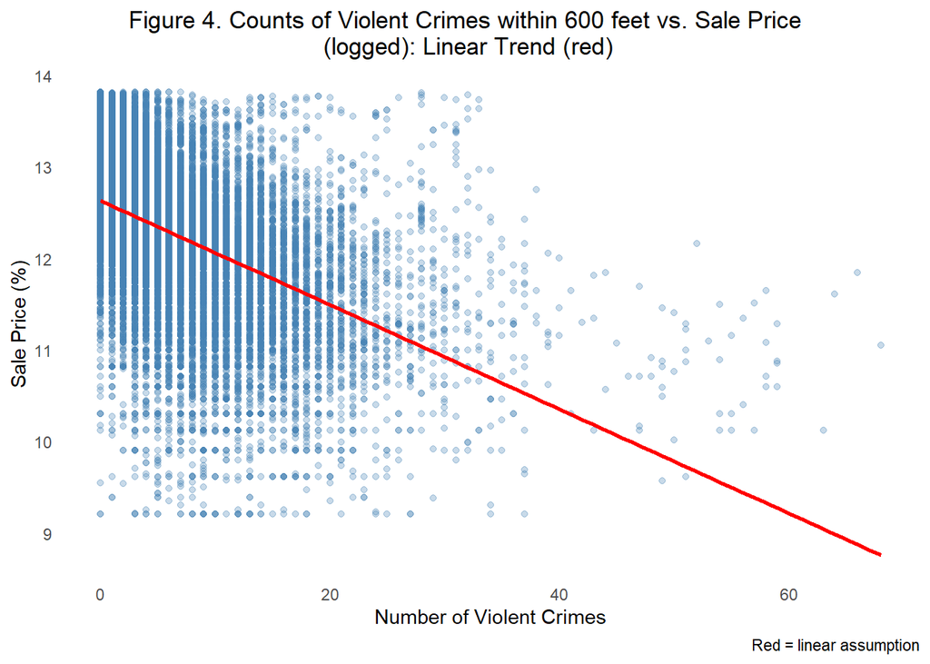

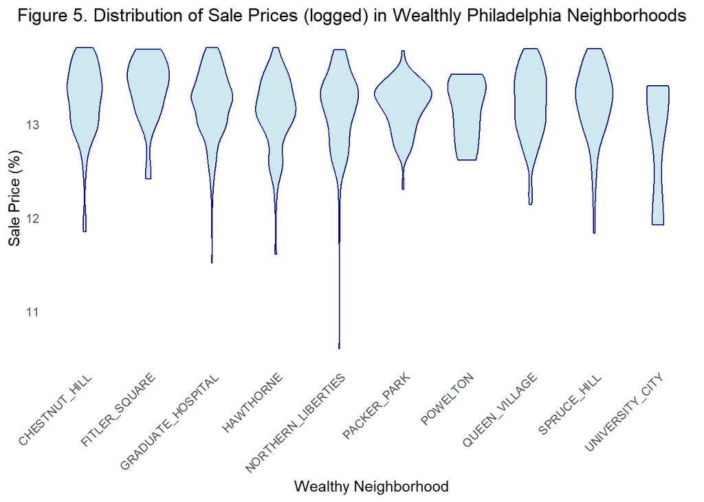

# Phase 3: Feature Engineering

In order to account for the spatial patterns highlight during the exploratory phase, we created a number of spatial features to incorporate into our predictive model.

**Code for Feature Engineering: Crime Buffer**

```r
#set crs for distance calculations
crime_proj <- st_transform(crime_data, 3365)
parcel_proj <- st_transform(parcel_data, 3365)
university_proj <- st_transform(university_data, 3365)

#proximity (within 600 feet) to violent crime

parcel_buffers<- st_buffer(parcel_proj, dist=600)

violent_crimes <- c("Homicide - Criminal","Aggravated Assault No Firearm","Robbery Firearm","Aggravated Assault Firearm")

violent_proj <- crime_proj %>%
  filter(text_gener %in% violent_crimes)

violent_crime_counts <- st_intersects(parcel_buffers, violent_proj)
violent_crime_counts <- lengths(violent_crime_counts)
parcel_data$violent_crime_600ft <- violent_crime_counts
```

**Code for Feature Engineering: K-Nearest Neighbor for Colleges**

```r
#knn to university

university_proj <- st_transform(university_data, 3365) #projection changed in order to calculate distance


dist_matrix <- st_distance(parcel_proj, university_proj)


get_knn_distance <- function(dist_matrix, k) {
  apply(dist_matrix, 1, function(distances) {
    mean(as.numeric(sort(distances)[1:k]))
  })
}

parcel_data$college_nn1 <- get_knn_distance(dist_matrix, k = 1)
parcel_data$college_nn3 <- get_knn_distance(dist_matrix, k = 3)
parcel_data$college_nn5 <- get_knn_distance(dist_matrix, k = 5)

#determine which nearest neighbor is correlated the most with sales price

parcel_data %>%
  st_drop_geometry() %>%
  select(sale_price, college_nn1, college_nn3, college_nn5) %>%
  cor(use = "complete.obs") %>%
  as.data.frame() %>%
  select(sale_price)
```

**Code for Feature Engineering: Neighborhood Interaction Effects**

```r
# wealthy neighborhood interaction effects
parcel_proj <- st_transform(parcel_data, 3365)
neighborhood_proj <-st_transform(neighborhoods, 3365)


#median sales price
wealthy_neighborhoods <- parcel_with_neighborhood%>%
  filter(median_price >= 275500)%>%
  pull(NAME)

#finding the parcels that fall within neighborhood boundaries
parcel_data <- parcel_proj %>%
  st_join(neighborhood_proj, join = st_within) %>%
  mutate(
    wealthy_neighborhood = ifelse(NAME %in% wealthy_neighborhoods, "Wealthy", "Not Wealthy"), #creating a flag to delineate them into two categories
    wealthy_neighborhood = as.factor(wealthy_neighborhood)
  )
```

Table 4. Summary of Engineered Features

| Feature_Name | Feature_Type | Description | Justification |
| --- | --- | --- | --- |
| violent_crime_600ft | Buffer-based (spatial) | Count of violent crimes within 600 ft of parcel | Captures neighborhood safety and crime exposure |
| college_nn1 | kNN (spatial distance) | Average distance to nearest college/university (k=1) | Measures proximity to educational amenities |
| college_nn3 | kNN (spatial distance) | Average distance to 3 nearest colleges/universities | Captures local educational accessibility |
| college_nn5 | kNN (spatial distance) | Average distance to 5 nearest colleges/universities | Captures broader proximity to higher education hubs |
| median_incomeE | Census (socioeconomic) | Median household income of census tract | Represents economic conditions of local area |
| percentage_bach | Census (education) | Percent of tract population with bachelor’s degree | Education level could be connected to property values |
| percentage_pov | Census (poverty) | Percent of tract population below poverty line | Reflects socioeconomic disadvantage |
| wealthy_neighborhood | Interaction term (categorical) | Indicates parcels located in wealthy neighborhoods | Identifies context of neighborhood wealth levels |
| log_sale_price | Transformation (continuous) | Natural log of sale price | Stabilizes variance for regression modeling |
| log_livable_area | Transformation (continuous) | Natural log of total livable area (sq ft) | Normalizes skewed size variable for modeling |
| Age | Structural (numeric) | Years since building construction | Accounts for devaluation of property value with time |
| exterior_good | Condition (binary) | 1 = good/average exterior, 0 = poor | Changed categorical condition to numeric to understand exterior desirability |

The features included were engineered to capture social, economic, and environmental factors influencing housing prices. Buffer-based and nearest-neighbor measures quantify local accessibility and safety. Census data enrich parcels with socio-economic context. Interaction terms account for neighborhood-level wealth effects which helps contextualize external features of a home, for instance homes in a wealthy neighborhood are more likely to have a higher property value than those not in a wealthy neighborhood. Applying a binary indicator improves model interpretability and performance.

# Phase 4: Model Building

When building our model’s be progressively built out models to expand upon the last with out first model being the baseline of all our models and using only structural variables, the second model adding socioeconomic census variables, our third model introducing our spatial features, and our fourth model added spatial interactions and fixed effects.

**Code for Model Building**

```r
#create log livable area for modeling

parcel_data <- parcel_data%>%
  mutate(log_livable_area = log(total_livable_area))

#structural features only
model1 <- lm(log_sale_price ~ number_of_bathrooms + number_of_bedrooms + log_livable_area + garage_spaces + Age + I(Age^2) + exterior_good, data = parcel_data)


#structural + census
model2 <- lm(log_sale_price ~ number_of_bathrooms + number_of_bedrooms + log_livable_area  + garage_spaces + Age + I(Age^2) + exterior_good + median_incomeE + percentage_bach + percentage_pov, data = parcel_data)

#structural + census + spatial
model3 <- lm(log_sale_price ~ number_of_bathrooms+ garage_spaces + Age + I(Age^2) + exterior_good + log_livable_area + median_incomeE +percentage_bach + percentage_pov + college_nn1 + violent_crime_600ft, data = parcel_data)


#structural + census + spatial + interactions
model4 <- lm(log_sale_price ~ number_of_bathrooms+ garage_spaces + Age + I(Age^2) + exterior_good + log_livable_area * wealthy_neighborhood + median_incomeE +percentage_bach + percentage_pov + college_nn1 + violent_crime_600ft, data = parcel_data)
```

Our summary table of coefficients for predictors by model indicate statistical numerically as well as with stars to account for low values omitted through the rounding of coefficients.

**Full Model Summary of Models**

Model 1

Model 2

Model 3

Model 4

(Intercept)

5.356***

7.176***

7.581***

7.195***

[5.099, 5.613]

[6.962, 7.391]

[7.395, 7.767]

[6.956, 7.435]

number_of_bathrooms

0.277***

0.211***

0.210***

0.205***

[0.264, 0.290]

[0.200, 0.222]

[0.199, 0.220]

[0.195, 0.216]

number_of_bedrooms

-0.199***

-0.017***

[-0.210, -0.187]

[-0.027, -0.008]

log_livable_area

0.894***

0.511***

0.464***

0.512***

[0.858, 0.930]

[0.481, 0.541]

[0.441, 0.488]

[0.480, 0.544]

garage_spaces

0.107***

0.100***

0.054***

0.055***

[0.092, 0.121]

[0.088, 0.112]

[0.042, 0.066]

[0.043, 0.067]

Age

-0.012***

-0.004***

-0.004***

-0.003***

[-0.013, -0.011]

[-0.004, -0.003]

[-0.005, -0.004]

[-0.004, -0.003]

I(Age^2)

0.000***

0.000***

0.000***

0.000***

[0.000, 0.000]

[0.000, 0.000]

[0.000, 0.000]

[0.000, 0.000]

exterior_good

1.207***

0.971***

0.900***

0.899***

[1.115, 1.299]

[0.896, 1.047]

[0.826, 0.974]

[0.826, 0.972]

median_incomeE

0.000***

0.000***

0.000***

[0.000, 0.000]

[0.000, 0.000]

[0.000, 0.000]

percentage_bach

1.554***

1.459***

1.104***

[1.465, 1.642]

[1.370, 1.549]

[1.012, 1.196]

percentage_pov

-0.887***

-0.505***

-0.419***

[-0.957, -0.817]

[-0.576, -0.433]

[-0.490, -0.349]

college_nn1

0.000***

0.000***

[0.000, 0.000]

[0.000, 0.000]

violent_crime_600ft

-0.020***

-0.018***

[-0.021, -0.019]

[-0.019, -0.017]

wealthy_neighborhoodWealthy

0.995***

[0.722, 1.269]

log_livable_area × wealthy_neighborhoodWealthy

-0.106***

[-0.144, -0.068]

Num.Obs.

25973

25866

25866

25866

R2

0.348

0.567

0.586

0.596

R2 Adj.

0.348

0.567

0.586

0.596

F

1982.775

3383.652

3332.011

2935.955

RMSE

0.61

0.50

0.48

0.48

- p < 0.1, * p < 0.05, ** p < 0.01, *** p < 0.001

As census variables are introduced in Model 2, median income, educational attainment, and poverty rate all show expected relationships: higher income and education levels are associated with higher sale prices, while higher poverty rates are negatively associated.Our spatial features introduced in Model 3, distance from the nearest college and density of crime were also identified as statistically significant. In Model 4, the coefficient for wealthy neighborhood is large and positive. There is, however, a slight negative interaction between log(livable area) and wealthy neighborhoods. This suggests that while larger homes still tend to sell for more, the appreciation of value of each additional square foot is less pronounced in already expensive areas.

Overall, the progression from Model 1 to Model 4 shows increasing explanatory power (R² rising from 0.35 to 0.60), and decreasing RMSE, indicating improved model fit as more structural and contextual variables are added.

# Phase 5: Model Validation

In order to further assess the predictive power of our models, we performed 10-fold cross validation for each model in order to determine how well the model predicts for unseen data.

**Code for 10-fold Cross-Validation**

```r
parcel_data <- na.omit(parcel_data)

ctrl <- trainControl(
  method = "cv",
  number = 10  # intiate 10-fold CV
)

model_cv1 <-  train(log_sale_price ~
                      number_of_bathrooms +
                      number_of_bedrooms +
                      log_livable_area +
                      garage_spaces +
                      Age + I(Age^2) +
                      exterior_good,
                     data = parcel_data,
                       method = "lm",
                       trControl = ctrl)


model_cv2 <- train(log_sale_price ~
                     number_of_bathrooms +
                     number_of_bedrooms +
                     log_livable_area  +
                     garage_spaces +
                     Age + I(Age^2) +
                     exterior_good +
                     median_incomeE +
                     percentage_bach +
                     percentage_pov,
                     data = parcel_data,
                      method = "lm",
                      trControl = ctrl
)


model_cv3 <- train(log_sale_price ~
                     number_of_bathrooms +
                     garage_spaces +
                     Age + I(Age^2) +
                     exterior_good +
                     log_livable_area +
                     median_incomeE +
                     percentage_bach +
                     percentage_pov +
                     college_nn1 +
                     violent_crime_600ft,
                     data = parcel_data,
                    method = "lm",
                    trControl = ctrl
)



model_cv4 <- train(log_sale_price ~
                     number_of_bathrooms+
                     garage_spaces +
                     Age + I(Age^2) +
                     exterior_good +
                     log_livable_area * wealthy_neighborhood +
                     median_incomeE +
                     percentage_bach +
                     percentage_pov +
                     college_nn1 +
                     violent_crime_600ft,
                     data = parcel_data,
                      method = "lm",
                    trControl = ctrl
)
```

Based on each model’s measurement average squared prediction error (RMSE), average absolute difference between predicted and actual values (MAE), and reported proportion of explained variance (R^2), we determined that Model 4’s inclusion of structural, socioeconomic, spatial, and interactive effects all contributed to smaller errors between predicted values and actual values and offered greater explanatory power.

Table 6. Cross-Validated Performance Metrics for Four Models

| Model | RMSE | Rsquared | MAE |
| --- | --- | --- | --- |
| Model 1 | 0.6079 | 0.3485 | 0.4542 |
| Model 2 | 0.4957 | 0.5667 | 0.3554 |
| Model 3 | 0.4842 | 0.5865 | 0.3434 |
| Model 4 | 0.4787 | 0.5958 | 0.3379 |

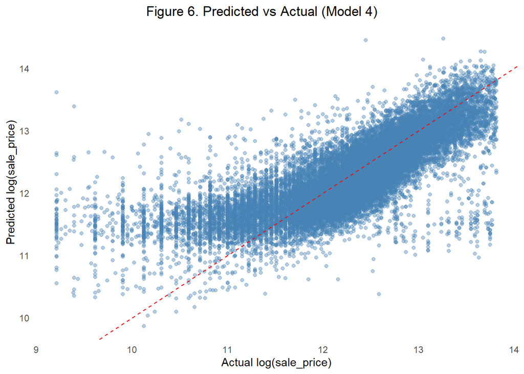

# Phase 6: Model Diagnostics

When using linear regression to model relationships, we assume a number of conditions are met to support the validity of using a linear model. Here we test various linear modeling assumptions to determine the appropriateness of our model.

One linear model assumption is the assumption that the relationship is actually linear. If the linearity assumption is met, residuals should be randomly scattered around the zero line with no discernible pattern.

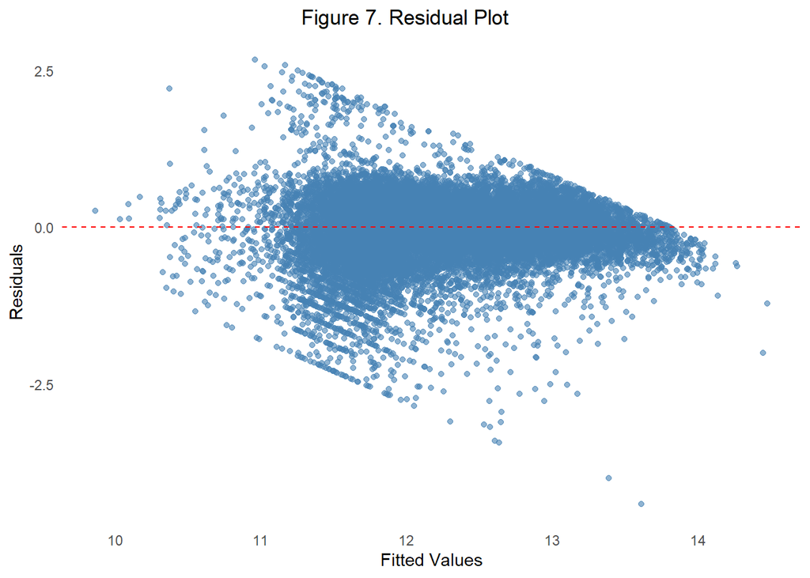

Another assumption we test is the normal distribution of residuals or errors. In Figure 8, we test the assumption of normally distributed residuals using a Q-Q plot. If normality of residual’s is met, the sample quantile points should fall roughly along the blue reference line representing theoretical quantiles of normal distribution.

In this plot, the residuals deviate from the line, particularly in the tails at low and high values, indicating non-normality.

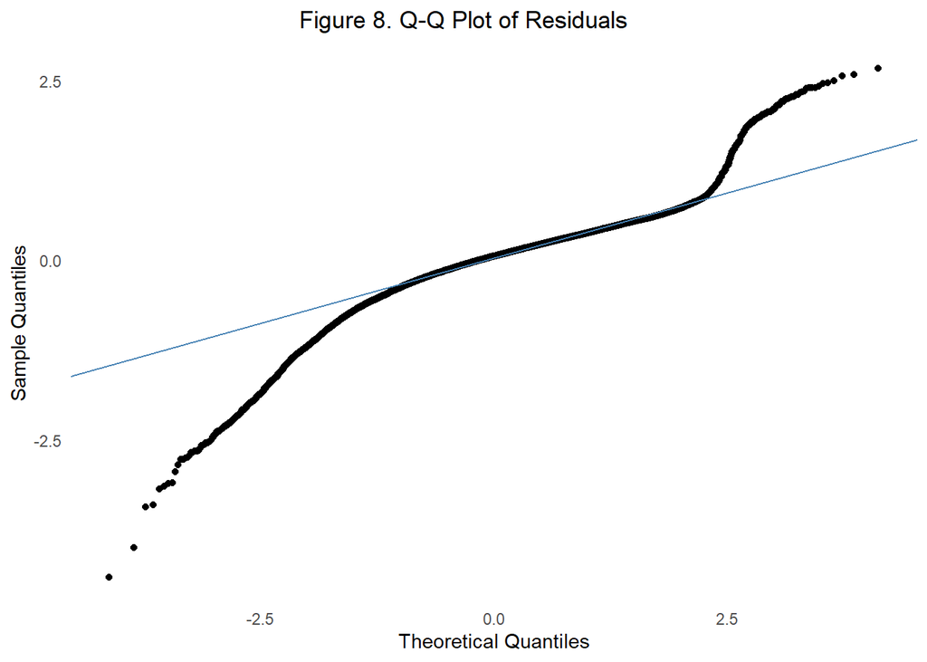

One last regression assumption check we performed was determining whether there were influential outliers present. Figure 9 displays Cook’s Distance values for each observation, with colors indicating whether the point is flagged as influential, blue being none influential observations and red being the influential obeservations. A substantial large number of our observations were marked as influential, suggesting that many data points have both high leverage and large residuals.

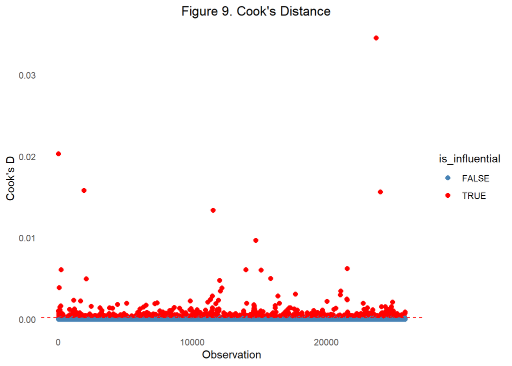

# Phase 7: Conclusions & Recommendations